# Activity monitoring data analysis

Fan Mo

3/4/2017

## Loading and preprocessing the data

Download and load the data into workspeace.

```r
library(ggplot2)
Url <- "https://d396qusza40orc.cloudfront.net/repdata%2Fdata%2Factivity.zip"
download.file(Url,"activity.zip")
unzip("activity.zip")
activity <- read.csv("activity.csv")
```

Transform the data “Date” to the date format.

```r
activity$date <- as.Date(activity$date)
```

## What is mean total number of steps taken per day?

Plot histogram of the total number of steps taken each day.

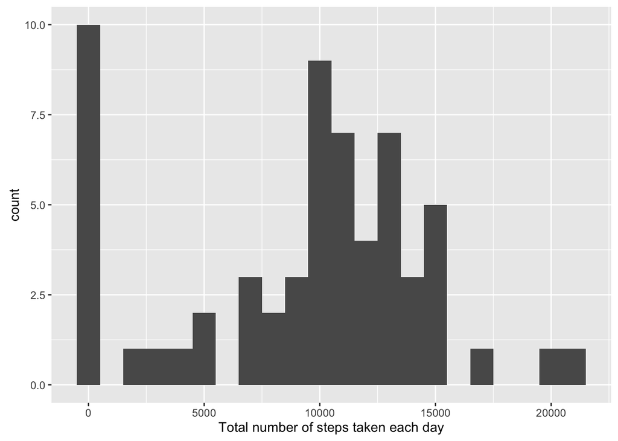

```r
library(ggplot2)
activitysteps <- tapply(activity$steps, activity$date, FUN=sum, na.rm=TRUE)
qplot(activitysteps, binwidth=1000, xlab="Total number of steps taken each day")
```

Calculate the mean and median number of steps taken each day.

```r
mean(activitysteps, na.rm=TRUE)
```

```
## [1] 9354.23
```

We can see the mean number of steps taken each day.

```r
median(activitysteps, na.rm=TRUE)
```

```
## [1] 10395
```

We can see the median number of steps taken each day.

## What is the average daily activity pattern?

Make the time series plot of the 5-minute interval and the average number of steps taken, averaged across all days.

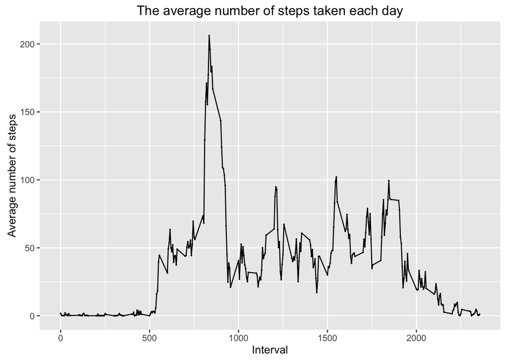

```r
activityint <- tapply(activity$steps, activity$interval, FUN = mean, na.rm = TRUE)
activityint <- data.frame(interval = as.numeric(names(activityint)),
                          meanstep = as.numeric(activityint))
ggplot(activityint,aes(x=interval,y=meanstep)) +
        geom_point(size=0.1) +
        geom_line() +
        ylab("Average number of steps") +
        xlab("Interval") +
        ggtitle("The average number of steps taken each day")
```

Calculate the maximum number of steps among those 5-minute interval.

```r
activityint$interval[(which(activityint$meanstep == max(activityint$meanstep)))]
```

```
## [1] 835
```

We can see that this 5-minute interval contains the maximum number of steps.

## Imputing missing values

Calculate the total number of missing values in the dataset.

```r
summary(activity$steps)[7]
```

```
## NA's
## 2304
```

We use the “summary” function to obtain the number of NAs in the dataset.

Create a new dataset and filling in all of the missing values in the dataset using mean steps in the associated day.

```r
activityfill <- activity # creat a new dataset
# create a dataframe to place the mean value
activitymean <- tapply(activity$steps, activity$date, FUN = mean, na.rm=TRUE)
activitymean <- data.frame(date = names(activitymean),
                           meanstep = activitymean,
                           state = rep("miss", times=length(activitymean)))
for(i in 1:length(activityfill$steps)){
        if(is.na(activityfill$steps[i])){
                locatetemp <- which(as.Date(activitymean$date) == activityfill$date[i]) # locate the NA value
                activityfill$steps[i] <- activitymean$meanstep[locatetemp] # inpute it using mean steps
                if(is.nan(activityfill$steps[i])){activityfill$steps[i] = 0} # replace NAN value using "0" value
        }
}
```

Plot histogram of the total number of steps taken each day based on filled data.

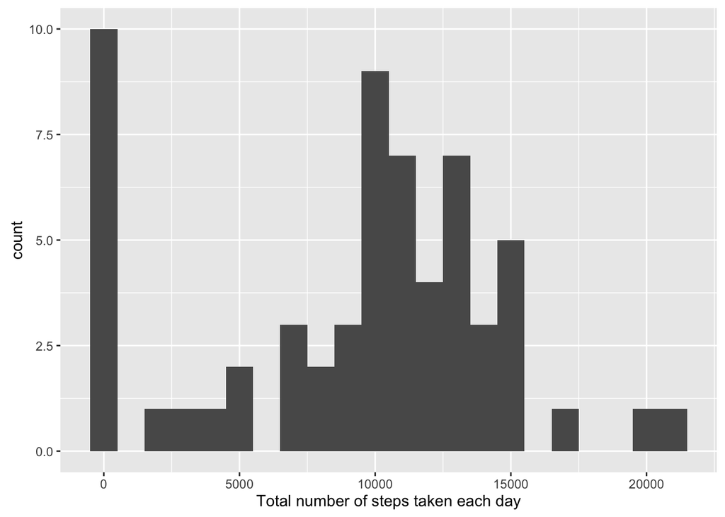

```r
activityfillsteps <- tapply(activityfill$steps, activityfill$date, FUN=sum)
qplot(activityfillsteps, binwidth=1000, xlab="Total number of steps taken each day")
```

Calculate the mean and median number of steps taken each day.

```r
mean(activityfillsteps)
```

```
## [1] 9354.23
```

```r
median(activityfillsteps)
```

```
## [1] 10395
```

Campare the data before and after filling miss data.

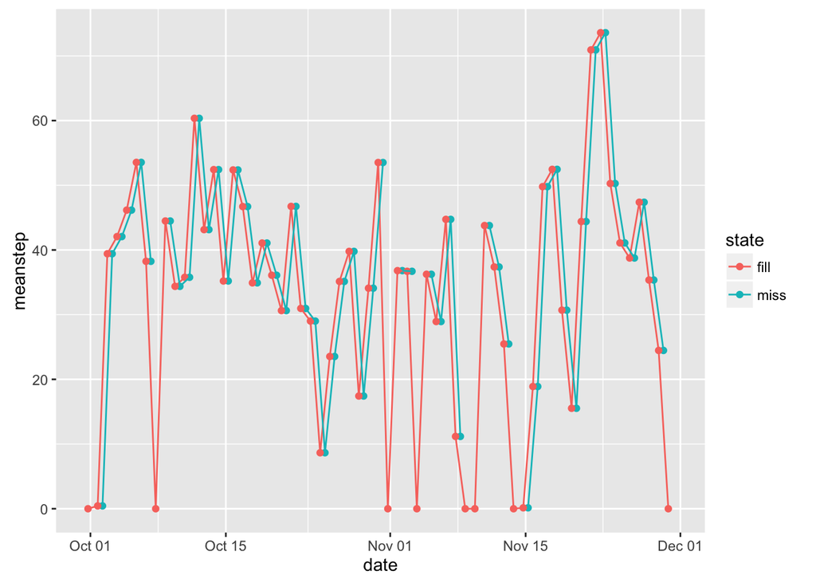

```r
activityfillmean <- tapply(activityfill$steps, activityfill$date, FUN = mean, na.rm=TRUE)
activityfillmean <- data.frame(date = names(activityfillmean),
                               meanstep = activityfillmean,
                               state = rep("fill", times=length(activityfillmean)))
# create a data.frame to store the miss and filled value data
activitycompmean <- rbind(activitymean, activityfillmean)
activitycompmean$state <- as.character(activitycompmean$state)
activitycompmean$date <- as.Date(activitycompmean$date)
pd <- position_dodge(1) # set the position value in ggplot
ggplot(activitycompmean, aes(x=date, y=meanstep, color=state, group=state)) +
        geom_point(position = pd) +
        geom_line(position = pd)
```

In the above figure, the points and lines of both miss data and filled data are very similar. The reason is that we used day’s average steps that relate to the miss records and it do not affect the mean value of day’s average steps. However, some of the NAs value are repleace.

Creat a factor variable and add it in the “activityfill” dataframe.

```r
activityfill$week <- weekdays(activityfill$date) # transfer date to weekdays
# repleace text "weekday"
activityfill$week <- sub("Monday|Tuesday|Wednesday|Thursday|Friday","weekday",activityfill$week)
activityfill$week <- sub("Saturday|Sunday","weekend",activityfill$week) # repleace text "weekend"
```

Make the panel plot containing a time series plot of the 5-minute interval and the average number of steps taken, averaged across all weekday days or weekend days.

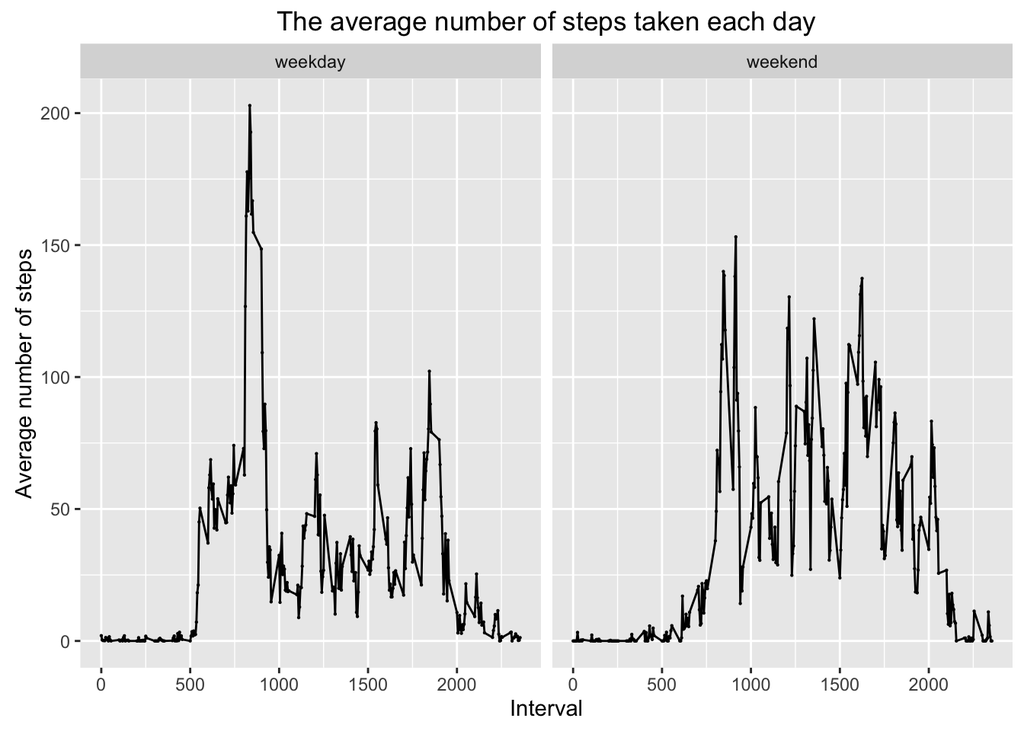

```r
# spilt weekday data and weekend data into two datasets
activityfilllist <- split(activityfill,activityfill$week)
# calculate mean steps per interval in both weekday datasets and weekend datasets
activityweekdayint <- tapply(activityfilllist[[1]]$steps, activityfilllist[[1]]$interval, FUN=mean, na.rm=TRUE)
activityweekendint <- tapply(activityfilllist[[2]]$steps, activityfilllist[[2]]$interval, FUN=mean, na.rm=TRUE)
# create data.frame to contain the data
activityweekdayint <- data.frame(interval = as.numeric(names(activityweekdayint)),
                              meanstep = as.numeric(activityweekdayint),
                              week = rep("weekday",times=length(activityweekdayint)))
activityweekendint <- data.frame(interval = as.numeric(names(activityweekendint)),
                                 meanstep = as.numeric(activityweekendint),
                                 week = rep("weekend",times=length(activityweekendint)))
# conbine the two data.frame into one
activityweekint <- rbind(activityweekdayint,activityweekendint)
# plot the figure
ggplot(activityweekint,aes(x=interval,y=meanstep)) +
        facet_grid(. ~ week) +
        geom_point(size=0.1) +
        geom_line() +
        ylab("Average number of steps") +
        xlab("Interval") +
        ggtitle("The average number of steps taken each day")
```

We can see that people usually have more steps in weekend, compared to those in weekday.